# NDVI Exploration

Adam M. Wilson

Let’s explore the LANDSAT data.

# Data

## Load LANDSAT data

```r
# LANDSAT 4
L4=stack(paste0(datadir,"ee_ZA_output/20140630_54ef46e7ea_LT4_L1T_ANNUAL_GREENEST_TOA__1982-1993-0000000000-0000000000.tif"))
NAvalue(L4)=0
gain(L4)=.01
names(L4)=paste0("Y",1982:1993)
L4=setZ(L4,1982:1993)

# LANDSAT 5
L5=stack(paste0(datadir,"ee_ZA_output/20140630_54ef46e7ea_LT5_L1T_ANNUAL_GREENEST_TOA__1984-2012-0000000000-0000000000.tif"))
NAvalue(L5)=0
gain(L5)=.01
names(L5)=paste0("Y",1984:2012)
L5=setZ(L5,1984:2012)

# LANDSAT 7
L7=stack(paste0(datadir,"ee_ZA_output/20140630_54ef46e7ea_LE7_L1T_ANNUAL_GREENEST_TOA__1999-2014-0000000000-0000000000.tif"))
NAvalue(L7)=0
gain(L7)=.01
names(L7)=paste0("Y",1999:2014)
L7=setZ(L7,1999:2014)

# LANDSAT 8
L8=stack(paste0(datadir,"ee_ZA_output/20140630_54ef46e7ea_LC8_L1T_ANNUAL_GREENEST_TOA__2013-2014-0000000000-0000000000.tif"))
gain(L8)=.01
NAvalue(L8)=0
names(L8)=paste0("Y",2013:2014)
L8=setZ(L8,2013:2014)
```

Let’s check out one of the LANDSAT objects. Raster provides a summary by just typing the object’s name:

```r
L7
```

```
## class       : RasterStack
## dimensions  : 1929, 1589, 3065181, 16  (nrow, ncol, ncell, nlayers)
## resolution  : 30, 30  (x, y)
## extent      : 222540, 270210, 6189390, 6247260  (xmin, xmax, ymin, ymax)
## coord. ref. : +proj=utm +zone=34 +south +datum=WGS84 +units=m +no_defs +ellps=WGS84 +towgs84=0,0,0
## names       :  Y1999,  Y2000,  Y2001,  Y2002,  Y2003,  Y2004,  Y2005,  Y2006,  Y2007,  Y2008,  Y2009,  Y2010,  Y2011,  Y2012,  Y2013, ...
## min values  : -327.7, -327.7, -327.7, -327.7, -327.7, -327.7, -327.7, -327.7, -327.7, -327.7, -327.7, -327.7, -327.7, -327.7, -327.7, ...
## max values  :  327.7,  327.7,  327.7,  327.7,  327.7,  327.7,  327.7,  327.7,  327.7,  327.7,  327.7,  327.7,  327.7,  327.7,  327.7, ...
## time        : 1999 - 2014 (range)
```

And a plot of the first year:

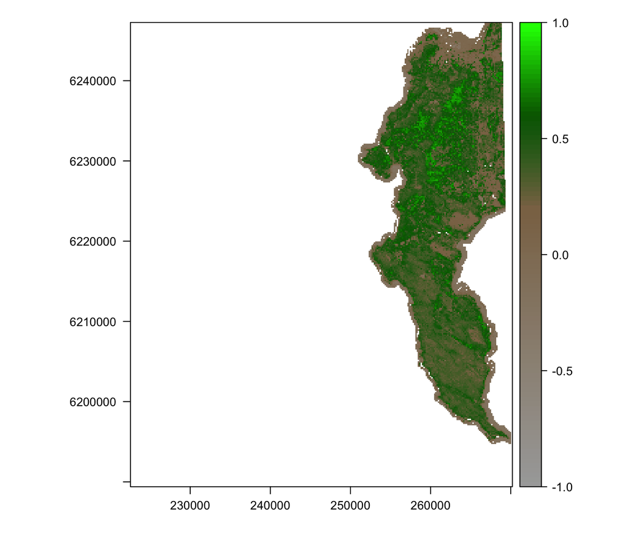

```r
levelplot(L7[[1]],col.regions=cndvi()$col,cuts=length(cndvi()$at),at=cndvi()$at,margin=F)
```

```r
peninsula=extent(250000,270210,6189390,6247260)
L7=crop(L7,peninsula)
```

Let’s try the plot again:

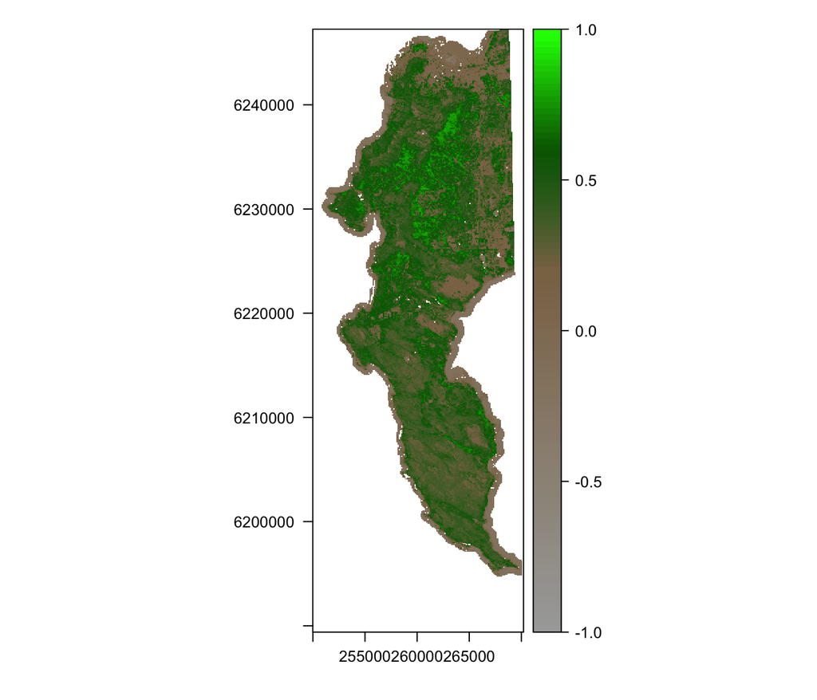

```r
levelplot(L7[[1]],col.regions=cndvi()$col,cuts=length(cndvi()$at),at=cndvi()$at,margin=F)
```

Much better. Now let’s look at the last few years.

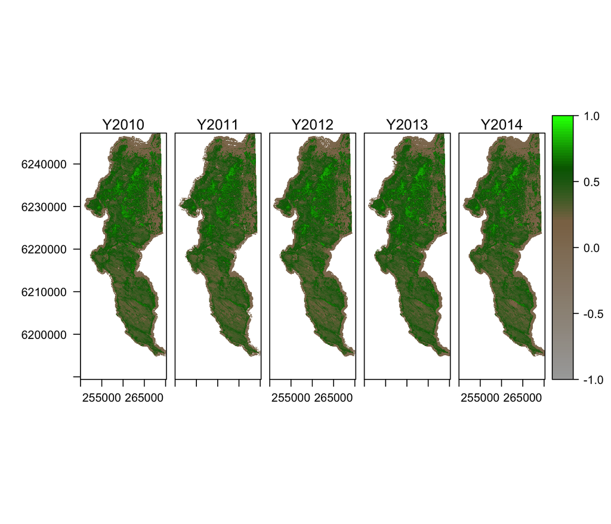

```r
levelplot(L7[[12:16]],col.regions=cndvi()$col,cuts=length(cndvi()$at),at=cndvi()$at,layout=c(5,1))
```

## Change through time

It’s still hard to see change, so let’s pick a pixel and plot NDVI as a function of time. But first we need to pick a pixel (or a few) to plot. There are a few ways to do this. First let’s try extracting values from a single cell:

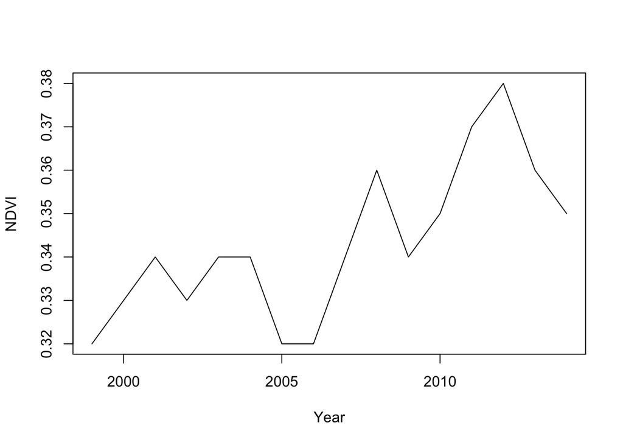

```r
plot(c(L7[199165])~getZ(L7),type="l",ylab="NDVI",xlab="Year")
```

Or, we can use the `click` function (in Raster) that allows you to pick points on the map. First we need to plot the data using the plot() command.

```r
## first plot the data
plot(L7[[1]])
## specify how many points you want to select
nclicks=5
d=click(L7,xy=T,n=nclicks,cell=T,id=TRUE,type="l")
## now click on the map to select your points

## reshape the data for easy plotting
d$id=1:nrow(d)
d2=melt(d,id.var=c("x","y","cell","id"));colnames(d2)=c("X","Y","Point","id","Year","NDVI")
d2$Year=as.numeric(sub("Y","",d2$Year))
p1=xyplot(NDVI~Year,groups=id,data=d2,type="l",auto.key=list(x=0,y=1))
p2=levelplot(L7[[1]],col.regions=cndvi()$col,cuts=length(cndvi()$at),at=cndvi()$at,margin=F)+
  layer(panel.text(d$x,d$y,d$id,col="red",cex=2))
print(c(p1,p2,merge.legends=T))
```

### Exercise:

1. Explore the map for areas you are familiar with. Do you see any patterns?
2. Can you identify any fires looking at the NDVI profiles?